# Assignment 1, EDDA 2017

Arash and Fabio, group 22

5 April 2017

## EXERCISE 1

If you place the file assign1.RData in your R-directory and type > load(file=“assign1.RData”) you will have data vectors x1, x2,…, x5 in your R working directory. Make a histogram and a QQ-plot for each of them, and decide which ones could have been sampled from a normal distribution. Experiment by simulating some normal samples of similar sizes and looking at their QQ-plots, before you make up your mind!

```r
load(file="assign1.RData")
```

### 1.1 Figures

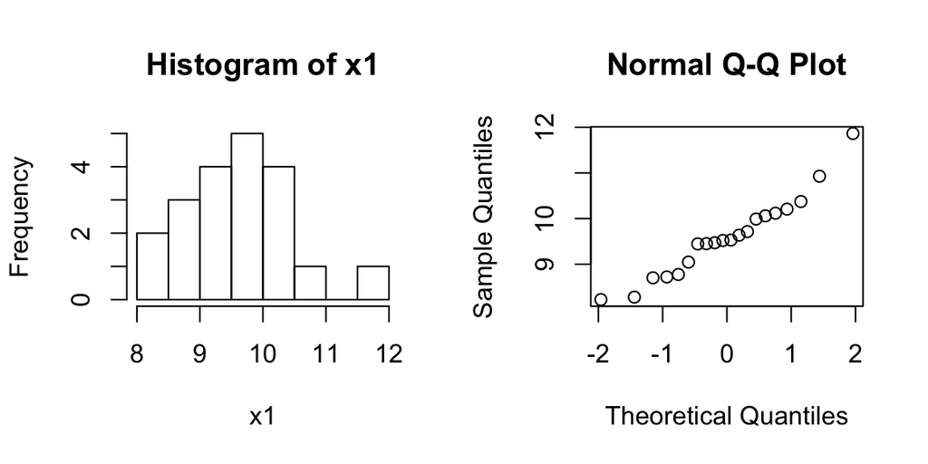

```
##
##  Shapiro-Wilk normality test
##
## data:  x1
## W = 0.95401, p-value = 0.432
```

```r
par(mfrow=c(1,2))
hist(x1); qqnorm(x1); shapiro.test(x1)
```

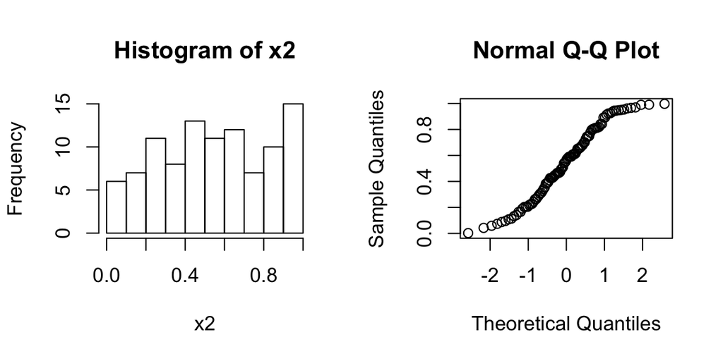

```
##
##  Shapiro-Wilk normality test
##
## data:  x2
## W = 0.95825, p-value = 0.003022
```

```r
hist(x2); qqnorm(x2);shapiro.test(x2)
```

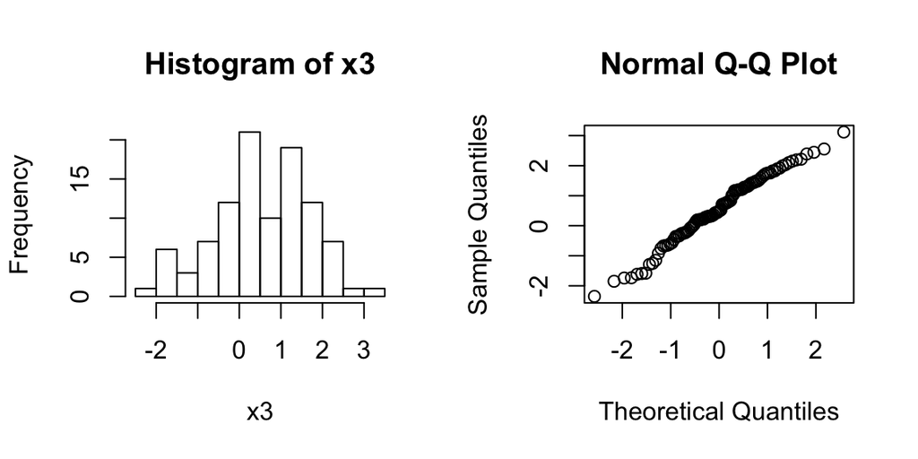

```
##
##  Shapiro-Wilk normality test
##
## data:  x3
## W = 0.98461, p-value = 0.2975
```

```r
hist(x3); qqnorm(x3);shapiro.test(x3)
```

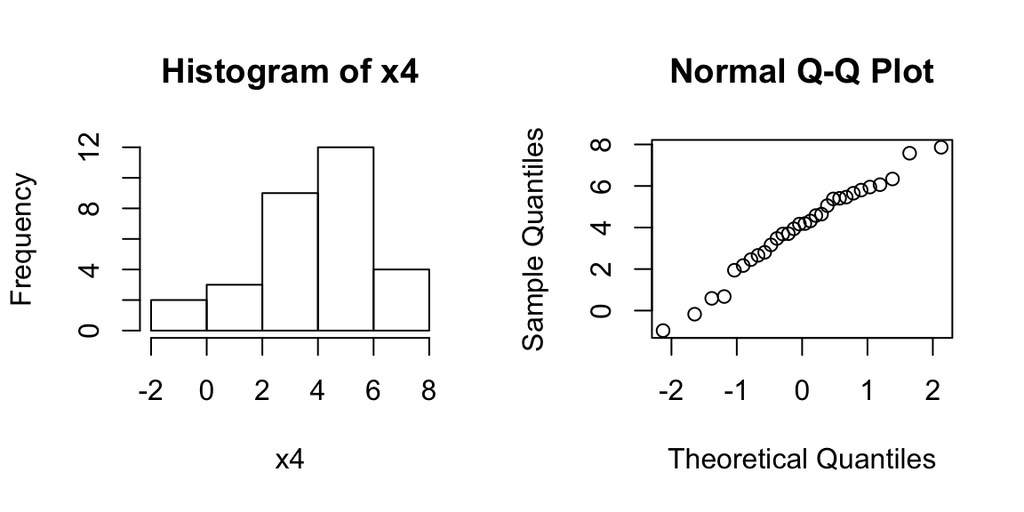

```
##
##  Shapiro-Wilk normality test
##
## data:  x4
## W = 0.97395, p-value = 0.6517
```

```r
hist(x4); qqnorm(x4);shapiro.test(x4)
```

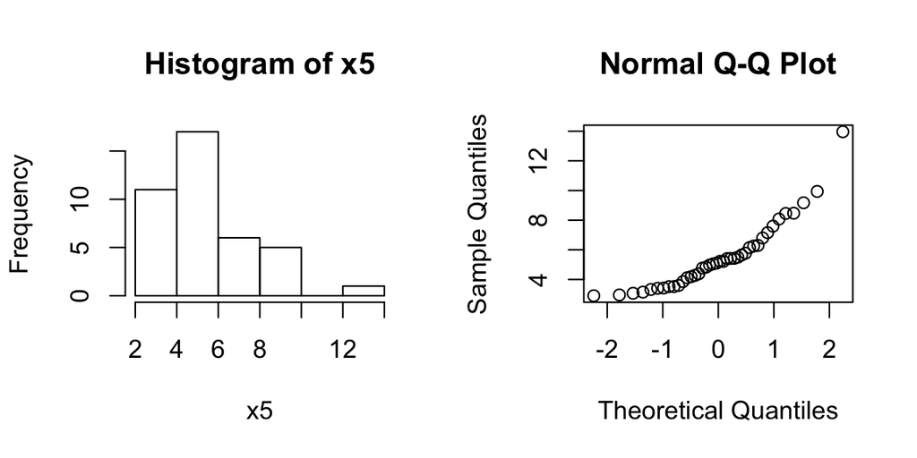

```
##
##  Shapiro-Wilk normality test
##
## data:  x5
## W = 0.86828, p-value = 0.0002581
```

```r
hist(x5); qqnorm(x5);shapiro.test(x5)
```

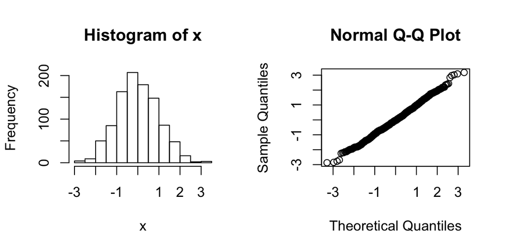

```r
x=rnorm(1000)
par(mfrow=c(1,2))
hist(x) ; qqnorm(x)
```

***

## Exercise 2

### 2.1 T-test

Below we perform a one sample t-test for the artificial date (that we generated ourselves).

```r
mu=0.2
x=rnorm(100,mu,1) # creating artificial data
t.test(x,mean=0)   # t.test(x,alternative=c("two.sided"),conf.level=0.95,mu=10)
```

```
##
##  One Sample t-test
##
## data:  x
## t = 2.117, df = 99, p-value = 0.03677
## alternative hypothesis: true mean is not equal to 0
## 95 percent confidence interval:
##  0.01258956 0.38883161
## sample estimates:
## mean of x
## 0.2007106
```

Of course, we often do not need to report the whole output of R-commands, only certain values of the output. For example, below we perform a two-smaple t-test and report only the value of t-statistics and the p-pavue.

```r
mu=0;nu=0.5
x=rnorm(50,mu,1); y=rnorm(50,nu,1) # creating artificial data
ttest=t.test(x,y)
```

The value of t-statistics in the above evaluation is -0.76 and the p-value is 0.4509.

# EXERCISE 2

```r
twoSampleT <- function(mu,nu,m,n,sd,pValue){
  B=1000
  p=numeric(B)
  c = 0
  for (b in 1:B) {
    x=rnorm(m,mu,sd)
    y=rnorm(n,nu,sd)
    p[b]=t.test(x,y,var.equal=TRUE)[[3]]
    if (p[b] < pValue){ c= c+1}
  }
  hist(p,main=c("with",pValue ))
}
```

```r
twoSampleTNU <- function(mu,nuMin,nuMax,nuStep,m,n,sd,pValue){
  B=1000
  p=numeric(B)
  power = numeric(B)
  for (nu in seq(nuMin,nuMax,by=nuStep)){
    for (b in 1:B) {
      x=rnorm(m,mu,sd)
      y=rnorm(n,nu,sd)
      p[b]=t.test(x,y,var.equal=TRUE)[[3]]
    }
    power[nu]=mean(p<pValue)
  }
  hist(power,main=c("with",pValue ))
}
```

### 1. Set mu=nu=180, m=n=30 and sd=10. Repeat the script 1000 times, and record the 1000 p-values. How many p-values are smaller than 5%? How many are smaller than 10%? What is the distribution of the p-values (make a histogram)?

```r
par(mfrow=c(1,2))
print(twoSampleT(180,180,30,30,10,0.05))
```

```
## $breaks
##  [1] 0.0 0.1 0.2 0.3 0.4 0.5 0.6 0.7 0.8 0.9 1.0
##
## $counts
##  [1] 100  91 107 119  93 120 112  82  88  88
##
## $density
##  [1] 1.00 0.91 1.07 1.19 0.93 1.20 1.12 0.82 0.88 0.88
##
## $mids
##  [1] 0.05 0.15 0.25 0.35 0.45 0.55 0.65 0.75 0.85 0.95
##
## $xname
## [1] "p"
##
## $equidist
## [1] TRUE
##
## attr(,"class")
## [1] "histogram"
```

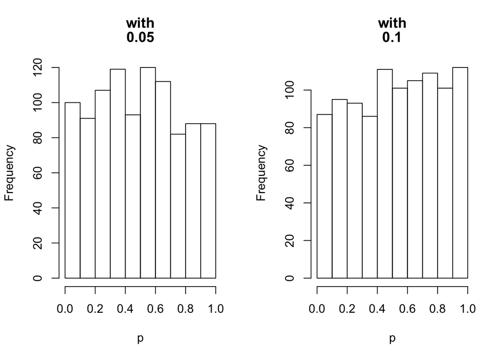

```
## $breaks
##  [1] 0.0 0.1 0.2 0.3 0.4 0.5 0.6 0.7 0.8 0.9 1.0
##
## $counts
##  [1]  87  95  93  86 111 101 105 109 101 112
##
## $density
##  [1] 0.87 0.95 0.93 0.86 1.11 1.01 1.05 1.09 1.01 1.12
##
## $mids
##  [1] 0.05 0.15 0.25 0.35 0.45 0.55 0.65 0.75 0.85 0.95
##
## $xname
## [1] "p"
##
## $equidist
## [1] TRUE
##
## attr(,"class")
## [1] "histogram"
```

```r
print(twoSampleT(180,180,30,30,10,0.10))
```

### 2. Set mu=nu=180, m=n=30 and sd=1. Answer the same questions.

```r
par(mfrow=c(1,2))
print(twoSampleT(180,180,30,30,1,0.05))
```

```
## $breaks
##  [1] 0.0 0.1 0.2 0.3 0.4 0.5 0.6 0.7 0.8 0.9 1.0
##
## $counts
##  [1]  84  93  93 118  94 113  97 123  84 101
##
## $density
##  [1] 0.84 0.93 0.93 1.18 0.94 1.13 0.97 1.23 0.84 1.01
##
## $mids
##  [1] 0.05 0.15 0.25 0.35 0.45 0.55 0.65 0.75 0.85 0.95
##
## $xname
## [1] "p"
##
## $equidist
## [1] TRUE
##
## attr(,"class")
## [1] "histogram"
```

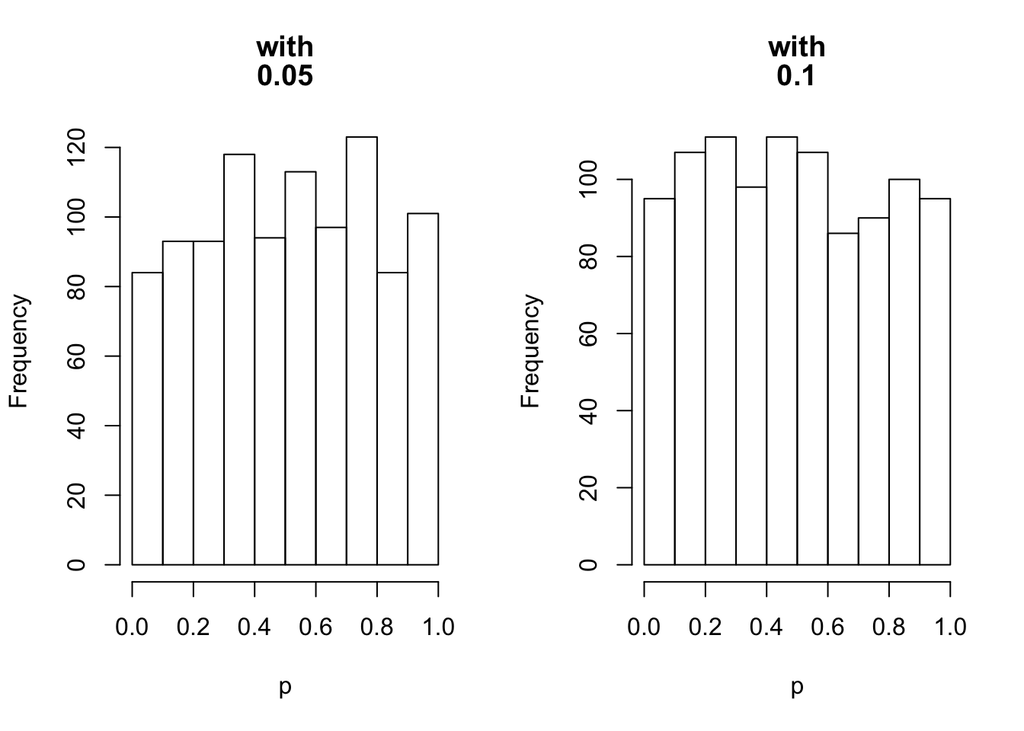

```
## $breaks
##  [1] 0.0 0.1 0.2 0.3 0.4 0.5 0.6 0.7 0.8 0.9 1.0
##
## $counts
##  [1]  95 107 111  98 111 107  86  90 100  95
##
## $density
##  [1] 0.95 1.07 1.11 0.98 1.11 1.07 0.86 0.90 1.00 0.95
##
## $mids
##  [1] 0.05 0.15 0.25 0.35 0.45 0.55 0.65 0.75 0.85 0.95
##
## $xname
## [1] "p"
##
## $equidist
## [1] TRUE
##
## attr(,"class")
## [1] "histogram"
```

```r
print(twoSampleT(180,180,30,30,1,0.10))
```

### 3. Set mu=180, nu=175, m=n=30 and sd=6. Answer the same questions.

```r
par(mfrow=c(1,2))
print(twoSampleT(180,175,30,30,6,0.05))
```

```
## $breaks
##  [1] 0.00 0.05 0.10 0.15 0.20 0.25 0.30 0.35 0.40 0.45 0.50 0.55 0.60 0.65
##
## $counts
##  [1] 891  50  21  16   7   6   0   5   0   1   0   1   2
##
## $density
##  [1] 17.82  1.00  0.42  0.32  0.14  0.12  0.00  0.10  0.00  0.02  0.00
## [12]  0.02  0.04
##
## $mids
##  [1] 0.025 0.075 0.125 0.175 0.225 0.275 0.325 0.375 0.425 0.475 0.525
## [12] 0.575 0.625
##
## $xname
## [1] "p"
##
## $equidist
## [1] TRUE
##
## attr(,"class")
## [1] "histogram"
```

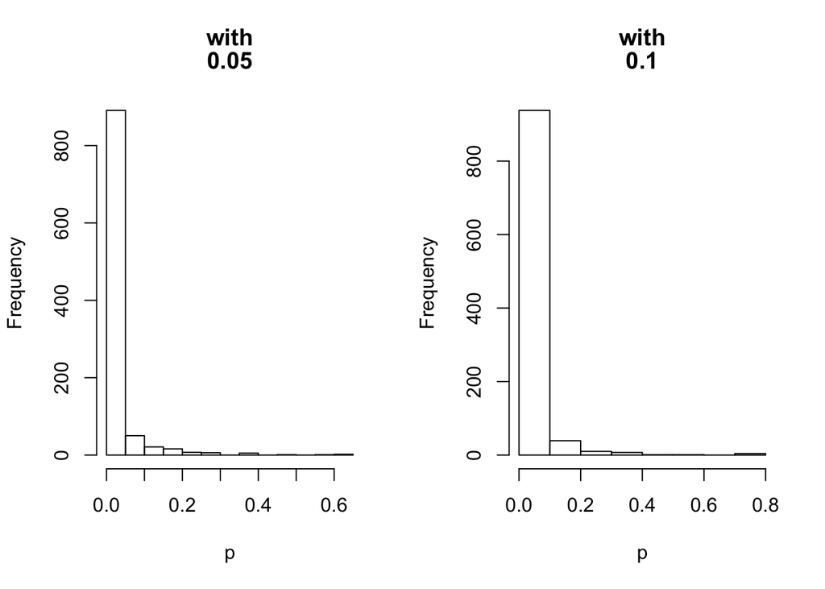

```
## $breaks
## [1] 0.0 0.1 0.2 0.3 0.4 0.5 0.6 0.7 0.8
##
## $counts
## [1] 938  39  10   7   1   1   0   4
##
## $density
## [1] 9.38 0.39 0.10 0.07 0.01 0.01 0.00 0.04
##
## $mids
## [1] 0.05 0.15 0.25 0.35 0.45 0.55 0.65 0.75
##
## $xname
## [1] "p"
##
## $equidist
## [1] TRUE
##
## attr(,"class")
## [1] "histogram"
```

```r
print(twoSampleT(180,175,30,30,6,0.10))
```

### 4. Explain the findings.

# EXERCISE 3

### 1. Set mu=180, m=n=30 and sd=5. Calculate the power of the t-test for every value of nu in the grid seq(175,185,by=0.1). Plot the power as a function of nu.

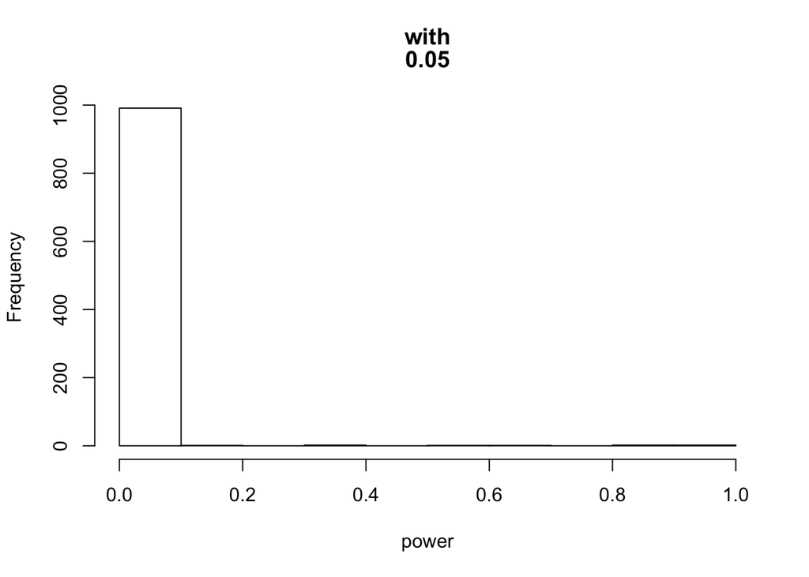

```
## $breaks
##  [1] 0.0 0.1 0.2 0.3 0.4 0.5 0.6 0.7 0.8 0.9 1.0
##
## $counts
##  [1] 991   1   0   2   0   1   1   0   2   2
##
## $density
##  [1] 9.91 0.01 0.00 0.02 0.00 0.01 0.01 0.00 0.02 0.02
##
## $mids
##  [1] 0.05 0.15 0.25 0.35 0.45 0.55 0.65 0.75 0.85 0.95
##
## $xname
## [1] "power"
##
## $equidist
## [1] TRUE
##
## attr(,"class")
## [1] "histogram"
```

```r
print(twoSampleTNU(180,175,185,0.1,30,30,5,0.05))
```

### 2. Set mu=180, m=n=100 and sd=5. Repeat the preceding exercise. Add the plot to the preceding plot.

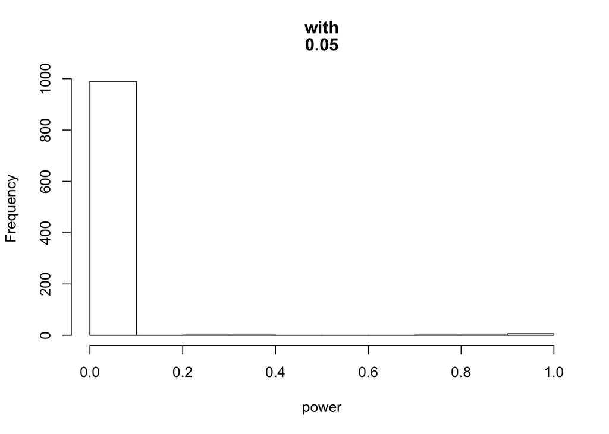

```
## $breaks
##  [1] 0.0 0.1 0.2 0.3 0.4 0.5 0.6 0.7 0.8 0.9 1.0
##
## $counts
##  [1] 990   0   1   1   0   0   0   1   1   6
##
## $density
##  [1] 9.90 0.00 0.01 0.01 0.00 0.00 0.00 0.01 0.01 0.06
##
## $mids
##  [1] 0.05 0.15 0.25 0.35 0.45 0.55 0.65 0.75 0.85 0.95
##
## $xname
## [1] "power"
##
## $equidist
## [1] TRUE
##
## attr(,"class")
## [1] "histogram"
```

```r
print(twoSampleTNU(180,175,185,0.1,100,100,5,0.05))
```

### 3. Set mu=180, m=n=30 and sd=100. Repeat the preceding exercise.

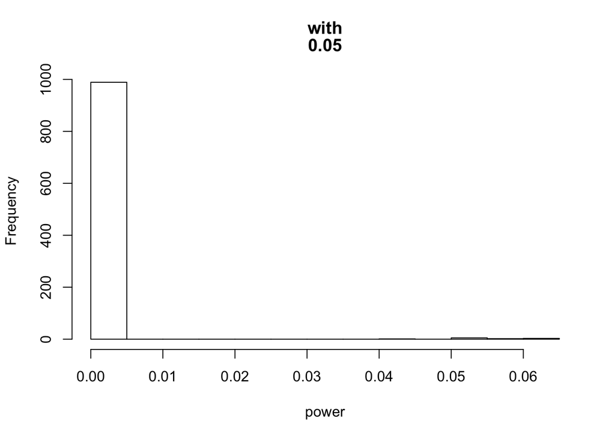

```
## $breaks
##  [1] 0.000 0.005 0.010 0.015 0.020 0.025 0.030 0.035 0.040 0.045 0.050
## [12] 0.055 0.060 0.065
##
## $counts
##  [1] 989   0   0   0   0   0   0   0   1   0   5   2   3
##
## $density
##  [1] 197.8   0.0   0.0   0.0   0.0   0.0   0.0   0.0   0.2   0.0   1.0
## [12]   0.4   0.6
##
## $mids
##  [1] 0.0025 0.0075 0.0125 0.0175 0.0225 0.0275 0.0325 0.0375 0.0425 0.0475
## [11] 0.0525 0.0575 0.0625
##
## $xname
## [1] "power"
##
## $equidist
## [1] TRUE
##
## attr(,"class")
## [1] "histogram"
```

```r
print(twoSampleTNU(180,175,185,0.1,30,30,100,0.05))
```

### 4. Explain the findings.